# Nutrient‐based species selection is a prevalent driver of community assembly and functional trait space in tropical forests - Peguero - 2023 - Journal of Ecology - Wiley Online Library

[Journal of Ecology](https://besjournals.onlinelibrary.wiley.com/journal/13652745)

[Volume 111, Issue 6](https://besjournals.onlinelibrary.wiley.com/toc/13652745/2023/111/6) p. 1218-1230

RESEARCH ARTICLE

Open Access

# Nutrient-based species selection is a prevalent driver of community assembly and functional trait space in tropical forests

[Guille Peguero](https://besjournals.onlinelibrary.wiley.com/authored-by/Peguero/Guille),

[Fernando Coello](https://besjournals.onlinelibrary.wiley.com/authored-by/Coello/Fernando),

[Jordi Sardans](https://besjournals.onlinelibrary.wiley.com/authored-by/Sardans/Jordi),

[Dolores Asensio](https://besjournals.onlinelibrary.wiley.com/authored-by/Asensio/Dolores),

[Oriol Grau](https://besjournals.onlinelibrary.wiley.com/authored-by/Grau/Oriol),

[Joan Llusià](https://besjournals.onlinelibrary.wiley.com/authored-by/Llusi%C3%A0/Joan),

[Romà Ogaya](https://besjournals.onlinelibrary.wiley.com/authored-by/Ogaya/Rom%C3%A0),

[Ifigenia Urbina](https://besjournals.onlinelibrary.wiley.com/authored-by/Urbina/Ifigenia),

[Leandro Van Langenhove](https://besjournals.onlinelibrary.wiley.com/authored-by/Van%C2%A0Langenhove/Leandro),

[Lore T. Verryckt](https://besjournals.onlinelibrary.wiley.com/authored-by/Verryckt/Lore+T.),

[Clément Stahl](https://besjournals.onlinelibrary.wiley.com/authored-by/Stahl/Cl%C3%A9ment),

[Laëtitia Bréchet](https://besjournals.onlinelibrary.wiley.com/authored-by/Br%C3%A9chet/La%C3%ABtitia),

[Elodie A. Courtois](https://besjournals.onlinelibrary.wiley.com/authored-by/Courtois/Elodie+A.),

[Jérôme Chave](https://besjournals.onlinelibrary.wiley.com/authored-by/Chave/J%C3%A9r%C3%B4me),

[Bruno Hérault](https://besjournals.onlinelibrary.wiley.com/authored-by/H%C3%A9rault/Bruno),

[Ivan A. Janssens](https://besjournals.onlinelibrary.wiley.com/authored-by/Janssens/Ivan+A.),

[Josep Peñuelas](https://besjournals.onlinelibrary.wiley.com/authored-by/Pe%C3%B1uelas/Josep),

First published: 04 March 2023

https://doi.org/10.1111/1365-2745.14089

Citations: 1

Guille Peguero and Fernando Coello contributed equally.

**Handling Editor:** James Dalling

## Abstract

en

1. Soil nutrient availability and functional traits interact in complex ways during the assembly of tree communities hindering our understanding of the implications that this may have for their phylogenetic and functional diversity.
2. We combined abundance, taxonomic, phylogenetic and functional trait data of 222 tree species distributed along nutrient concentration gradients at 24 plots in two tropical forest study sites. We analysed micro and macronutrient concentration in organic and topsoil horizons and tested for the following: (1) nutrient-based species sorting due to contrasting trait–environment relationships, (2) whether nutrient filtering has consequences for phylogenetic and functional diversity, and functional space size and occupancy and (3) we mapped trait distributions across the phylogeny of tree species to track the evolutionary signature of nutrient availability.
3. We found that total nitrogen (N), available phosphorus and total potassium in soil accounted for 68% of the variation in tropical tree species community composition, with strong associations with nutrient concentration for 89% of the tree species included in the analysis. This nutrient-based species selection was mediated by interactions between the three soil nutrient concentrations with leaf nitrogen, leaf thickness and wood density. Soil N concentration was positively associated with the functional space at site level. At plot level, soil N concentration positively correlated with functional evenness and it was negatively associated with the functional space not occupied by any species in the tree community. Despite the phylogenetic conservatism of leaf N across tree lineages even when not considering legumes, many sister-species pairs show contrasting values which match with their habitat preferences thus indicating the evolutionary lability of this trait, particularly within recently diversified clades.
4. *Synthesis*. Our results demonstrate that soil nutrient-based species selection is a prevalent driver of community assembly in tropical forests, a process mediated by key functional traits within the leaf and wood economics spectrum. Functional space size and its filling increase with soil nutrient concentration, whereas niche vacancy decreases. This selection process has likely influenced tropical tree species diversification patterns via habitat specialization.

## Resumen

es

1. La disponibilidad de nutrientes en el suelo interacciona de manera compleja con los atributos funcionales durante el ensamblado de las comunidades de árboles, dificultando nuestra comprensión de las implicaciones que esto puede conllevar sobre la diversidad funcional y filogenética de estas comunidades.
2. Combinamos datos de abundancia, composición taxonómica, diversidad filogenética y atributos funcionales de 222 especies de árboles distribuidas a lo largo de gradientes naturales de nutrientes en el suelo en 24 parcelas en dos áreas de estudio de bosque tropical. Analizamos la concentración de micro y macro nutrientes en los horizontes orgánico y superior y testamos: (1) el filtrado de especies árboles en función de los nutrientes debido a relaciones atributo-ambiente contrastantes; (2) si el filtrado por nutrientes tiene consecuencias para la diversidad filogenética y funcional así como para el espacio funcional total y su ocupación; y (3) mapeamos las distribuciones de atributos en la filogenia de las especies de árboles para rastrear el señal evolutivo de la disponibilidad de nutrientes.
3. El nitrógeno total (N), el fósforo disponible (P) y el potasio total (K) dieron cuenta del 68% de la variación composicional de las comunidades de árboles, con el 89% de las especies analizadas mostrando asociaciones fuertes con al menos uno de los nutrientes. Esta selección basada en los nutrientes fue mediada por interacciones entre las concentraciones de estos tres nutrientes con atributos como el N en hoja, el grosor de la hoja o la densidad de la madera. La concentración de N en el suelo estuvo positivamente asociada con el espacio funcional total a nivel de sitio, y a nivel de parcela correlacionó positivamente con la equitatividad funcional y negativamente con la cantidad de espacio funcional vacío no ocupado por ninguna especie. A pesar de la elevada conservación filogenética del contenido de N en hoja, a través de todos los linajes de árboles e incluso sin considerar a las leguminosas, muchos pares de especies hermanas muestran valores contrastantes que encajan con sus preferencias de hábitat indicando así la labilidad evolutiva de este atributo clave, especialmente en los clados de diversificación reciente.
4. Síntesis. Nuestros resultados demuestran que la selección de especies de árboles ejercida por los nutrientes del suelo es un factor director predominante durante el ensamblado de las comunidades de bosques tropicales, un proceso mediado por atributos funcionales clave dentro del espectro económico de hoja y madera. El espacio funcional y su ocupación aumentan con la concentración de N en el suelo, mientras que los nichos vacantes decrecen. Este proceso de selección probablemente ha influido en los patrones de diversificación de las especies tropicales de árboles a través de la especialización por hábitat.

## 1 INTRODUCTION

Since the revival of plant community ecology by fully embracing the information provided by functional traits, the relationships between the fundamental and realized ecological niches of plant species with their abiotic and biotic context have been hypothesized to be mediated by their traits (McGill et al., 2006; Webb et al., 2002). Thus, the classical expectation of a correlation between environmental conditions and plant species composition (Tansley, 1917, 1939) was accordingly revised to include means, ranges and variances of traits, and if those measurements departed from a given random distribution, as indicated by clustering or even-spacing, this would provide indirect evidence for environmental filtering or competitive exclusion (Baraloto et al., 2012; Cornwell et al., 2006; Diaz et al., 1998; Kraft et al., 2008; Swenson & Enquist, 2009). Hence, it has been hypothesized that functional traits ultimately drive the assembly of plant communities due to their predicted linkage with species demographic performance, so that the spatial distribution of functional traits should mirror key environmental gradients (McGill et al., 2006; Vellend, 2017). Yet, beyond some remarkable studies (Adler et al., 2014; Cornwell & Ackerly, 2009; Diaz et al., 1998; Hérault et al., 2011; Pavoine et al., 2011), finding evidence of such trait–demographic and trait–environment relationships has proven elusive (Paine et al., 2015; Warton et al., 2015).

A common way to uncover assembly mechanisms is the assessment of changes in the phylogenetic and functional diversity of communities (Mason et al., 2013; Tucker et al., 2017). While phylogenetic diversity is the amount of evolutionary history present in a given community (Faith, 1992), functional diversity is defined as the value and range of the functional traits of the organisms in a given biotic assemblage (Tilman, 2001). Indicators of functional diversity are typically related to functional richness, that is, the amount of multivariate trait space occupied by species in a community, functional evenness, which accounts for the regularity of abundance distributions across the occupied trait space, and functional divergence, representing disparities in abundance distributions across the occupied trait space (Mason et al., 2005). Analogous indicators of richness, regularity and divergence have been developed to inform about the phylogenetic structure of ecological communities (Tucker et al., 2017). Although these are intuitive metrics, the interpretation of the community assembly process from phylogenetic and functional diversity patterns can be problematic. For example, from a pattern of phylogenetic clustering combined with trait conservatism, we can infer that the community assembly has been driven either by competitive exclusion or by environmental filtering, depending on whether species coexistence is maintained by equalizing mechanisms that reduce fitness differences between species or by niche differences, respectively (Mayfield & Levine, 2010).

Inferences about the filling of available ecological niches in a community are based on the implicit assumption that trait axes are proxies for niche axes (Westoby et al., 2002). The functional space occupied by a community can be quantified by calculating its trait hypervolume, which describes the phenotypic space filled by all species in the community (Blonder et al., 2014). This multidimensional space includes the effects of not only abiotic factors (e.g. soil and climate) but also biotic interactions (e.g. resource competition), which may result in particular hypervolume geometries (Blonder et al., 2014). Thus, abiotic and biotic factors can constrain the ecological functions expressed in a stressful or limiting habitat, reducing the whole functional hypervolume of a community or enlarging it in some specific dimensions (Blonder et al., 2014). Additionally, the number of species per unit of hypervolume, and the ratio between the empty functional space over the whole hypervolume (the hole ratio) are expected to inform about either the niche packing and the vacant niches present in a community, respectively (Blonder, 2016; Lamanna et al., 2014).

Globally, tropical forests are large biodiversity reservoirs and they contribute disproportionately to biogeochemical cycles, so an understanding of their functioning should provide an opportunity to improve forecasts of biodiversity loss and impacts on Earth system dynamics (Malhi, 2012; Swenson, 2013). Given the high levels of biodiversity turnover and spatial heterogeneity of environmental conditions, such as nutrient availability (John et al., 2007; Peguero et al., 2021; Tuomisto et al., 2003), tropical forests represent an ideal ecosystem to explore relationships between environmental properties, functional traits and community assembly (Swenson, 2013). For example, topographic features, such as slope and ruggedness, influence tropical forest hydrologic regimes, with associated impacts on soil weathering, mineralogy and texture that determine nutrient concentration and availability (Van Langenhove et al., 2020; Weintraub et al., 2015). This in turn modulates traits and species distribution patterns (Baraloto et al., 2021; Clark et al., 1998; Condit et al., 2013; John et al., 2007; Kraft et al., 2008). Moreover, it is likely that this nutrient-related habitat specialization has left an evolutionary signature on tree species' elemental composition and their phylogenetic patterns (Fine et al., 2005; Sardans et al., 2021; Schmitt et al., 2021). However, the role of phosphorus (P) as the most limiting nutrient in tropical forests (Sardans et al., 2012; Turner et al., 2018; Vitousek, 1984) is challenged by evidence that other macronutrients, such as nitrogen (N), and micronutrients (sensu Kaspari, 2021) like potassium (K), also impact tree species growth and reproduction (Santiago et al., 2012; Wright, 2019; Wright et al., 2018). The influence of functional traits on community assembly and their relationships with the environment have tended to be assessed either indirectly, by testing for changes in statistical distribution parameters (Baraloto et al., 2012; Kraft et al., 2008; Swenson & Enquist, 2009), or directly, using multivariate ordination and resampling-based hypothesis testing (Legendre et al., 1997); however, both approaches largely ignore effects of covariation in species responses to environmental conditions and potentially underestimate the importance of species interactions, including competition and facilitation (Warton et al., 2015).

In this study, we investigated how soil nutrient availabilities interact with functional traits to drive the assembly of tree communities and the consequences for their phylogenetic and functional diversity as well as the size and occupation of their functional trait space. We addressed these research questions by combining abundance, taxonomic, phylogenetic and functional trait data for 222 tree species in two topographically similar tropical forests covering local and regional scale natural differences in soil nutrient concentration. By mapping functional trait distributions and reconstructing their ancestral states across the tree species phylogeny, we evaluated the potential signature of nutrient availability during tree species diversification in tropical forests.

## 2 MATERIALS AND METHODS

### 2.1 Study sites and experimental design

TABLE 1. Details of study site location and climate, and analysis of study site differences in soil properties and measures of tree species diversity.

|  | Nouragues | Paracou |
| --- | --- | --- |
| Lat/long coordinates | 04°04′53″N, 52°42′13″W | 05°16′38″N, 52°55′38″W |
| Main soil type (FAO) | Acrisols | Acrisols |
| Mean annual temperature | 25.2°C | 25.8°C |
| Mean annual precipitation | 2874 mm | 3150 mm |
| Dry season | 3 months | 3 months |
| Tree abundance per hectare | 19.63 ± 6.4 | 24.94 ± 6.3 |
| Tree species richness per hectare | 10.33 ± 3.9 | 8.77 ± 2.9 |
| Tree species α-diversity | 3.4 ± 0.1 | 3.0 ± 0.1* |
| Soil nitrogen concentration (%) | 0.26 ± 0.043 | 0.17 ± 0.033*** |
| Soil phosphorus concentration (ppm) | 1.705 ± 0.0.35 | 1.522 ± 0.52 |
| Soil potassium concentration (%) | 0.13 ± 0.55 | 0.15 ± 0.85*** |

- *Note*: Data for tree species abundance, richness, and diversity (*N* = 24), and soil nutrient concentration (*N* = 120) are mean (±SE). Study site differences in measures of tree species diversity and soil nutrient concentration were tested using linear mixed-effects models, with site and plot topographic position as fixed effects terms for analysis of tree species diversity and plot as a random effect nested within site and topography for analysis of soil nutrient concentration. There were interactions between site and plot topographic position for all soil nutrients; see Table S3 for output summaries of nutrient models.
- * *p* < 0.05
- *** *p* < 0.001.

### 2.2 Tree and soil sampling

Across the study plots, we mapped 2139 individual trees with a diameter at breast height ≥10 cm; the trees were then identified and classified into 222 tree species using herbarium voucher specimens and based on the fully resolved and dated phylogeny generated at these sites (Baraloto et al., 2012). Additionally, we obtained data for 13 functional traits from the BRIDGE database (Baraloto et al., 2012). These traits are associated with key leaf and stem functions: tree bark thickness, sapwood density and moisture content, twig diameter, xylem density and bark thickness to represent stem structure, defence and transport efficiency; foliar concentration of N, carbon (C) and chlorophyll, foliar C:N ratio, and leaf toughness, thickness and dry mass to represent leaf resource capture and performance; and, leaf toughness, thickness and dry mass, foliar C concentration and ratio of C:N to represent leaf structure and defence (Table S1). The functional traits present in the BRIDGE database were gathered from the same sites as this study (Baraloto et al., 2012).

A single 20-m<sup>2</sup> quadrat was placed in the centre of each plot, in which five evenly spaced sampling points were established for soil core and litter sampling (*N* = 120). Three soil cores (4 cm diameter, 30 cm long) were sampled at each point, where the 0–15 and 15–30 cm profiles were separately combined to form single composite samples of topsoil and deep soil per point. Litter was collected from a 20-cm<sup>2</sup> quadrat at each five sampling points and litter samples were immediately oven-dried at 60°C until reaching constant weight. Soil and litter concentrations of C and N were analysed with an elemental analyser (Elementar Vario EL Cube or Micro Cube; Elementar Analysensysteme GmbH). Soil and litter concentrations of P, K, calcium, magnesium and sodium were measured using inductively coupled plasma mass spectrometry (ICP-MS Agilent 7500; Thermo Fisher Scientific, Germany). Soil available P was determined using the Olsen and Bray methods. See Urbina et al. (2021) and (Van Langenhove, 2020) for further methodological details as they are the original source of soil data.

### 2.3 Data analyses

We used linear mixed-effects models, in the lme4 r package (Bates et al., 2020), to test for site and topographic location differences in tree abundance, species richness and diversity and soil nutrient concentrations, with study site and topography as fixed-effects terms in the tree models and plot as a random effect nested within site and topography in the soil nutrient models. Best models were selected according to goodness of fit, likelihood-ratio tests (LRTs) and explanatory power. Overall performance and assumptions were assessed using residual diagnostics.

Effects of micro and macronutrients on tree community composition were tested using generalized linear latent variable models (GLLVMs) in the r package gllvm (Niku et al., 2019). GLLVM allows the analysis of multivariate community abundance data ranging from low numbers of species to high-dimensional assemblages comprising thousands of taxonomic units (Niku et al., 2019), always including latent variables which can be interpreted as missing predictors or unmeasured environmental variables capturing the main axes of abundance co-variation after controlling for the constraining predictors specified (Warton et al., 2015). Based on goodness-of-fit and residual diagnostics, we built a GLLVM with a zero-inflated Poisson distribution, with a log-link function and two latent variables that excluded environmental predictors, following Niku et al. (2019), as a model-based unconstrained ordination; the resulting ordination plot uses the latent variables as axes to provide a graphical representation of study plot similarity, based solely on species composition. The addition of environmental variables to the model allows the ordination of study plots, based on the similarity of species composition, while controlling for effects on species of environmental factors (Niku et al., 2019; Warton et al., 2015); therefore, we iterated all possible combinations of our nutrient variables as constraining environmental predictors in the GLLVM, limiting the maximum number of nutrient variables to three, due to the high computational demands of GLLVM. This procedure resulted in 344 models that were ranked according to their second-order Akaike Information Criterion (AICc) and LRTs were used to assess the predictive improvement of two competing models; when differences were detected, we calculated the proportional increase (%) in deviance explained by the best model.

GLLVM can be used as fourth corner models, where multivariate abundance data are regressed as a function of species traits and environmental predictors to test for trait–environment interactions (Niku et al., 2019; Warton et al., 2015). Therefore, we tested the interaction of the three most informative functional traits with the nutrient variables in the best environmentally constrained model. The traits were selected based on the two traits with the highest loadings in the first two axes of a principal component analysis (PCA) (% leaf N concentration and sapwood density) and the trait with the most orthogonal vector to the other two (leaf thickness; Figure S1). Interactions between functional traits and soil nutrients were confirmed when 95% confidence intervals (CI) of each trait-environment coefficient did not overlap zero and while whole model significance was evaluated using LRT between nested models with or without trait interactions (Niku et al., 2019). Following Baraloto et al. (2010), we also carried out the same fourth-corner model using the PCA scores of the first and second axes as surrogates for the leaf and stem economics spectrum; the performance of this model (i.e. δAICc >2) was lower than that in which the combination of three traits was used, so it was discarded. Finally, we repeated the same GLLVM analyses only including the 72 tree species that had more than five individuals recorded to assess the sensitivity of the results to the commonness or rarity of tree species.

We tested for study site differences in phylogenetic community structure and functional diversity: for each study plot we calculated phylogenetic diversity and mean nearest taxon distance and mean variance of nearest taxon distance using the picante and pez packages (Kembel et al., 2010; Pearse et al., 2015) and functional trait richness (the amount of functional space filled by the community), evenness (the evenness of abundance distribution in a functional trait space), divergence (the spread along a functional space) and dispersion (the mean distance in multidimensional trait of an individual species to the centroid of all species) using the dbFD function of the fd package. The functional and phylogenetic metrics were standardized against 999 randomized independent swap null communities to control for plot differences in species richness (Swenson, 2014). We analysed trait hyperspace as a metric for occupation of functional space at the two study sites, which was computed through Gaussian kernel density estimation using the r package hypervolume (Blonder et al., 2018). Calculation of volume was based on the same three most informative traits selected for the GLLVMs above, for species present at the study site or at plot level, and each volume was constructed using a threshold quantile of 0.05; consequently, each volume includes 95% of the total probability density, based on 500 Monte Carlo samples per data point, and an estimated variable kernel bandwidth for each axis (Blonder et al., 2018). Thus, we obtained the overlap and unique areas of the functional space occupied by the tree communities at site or plot level, where overlap was calculated by the intersection volume divided by the union volume. We estimated the number of species per unit of plot-level trait volume as a measure of niche packing, and hole ratios at site and plot levels (i.e. the empty functional trait space) as the ratio between the volume of the detected holes and the volume of the convex expectation, as a measure of vacant niches (Blonder, 2016).

We tested the differences in functional and phylogenetic metrics between study sites, topographic positions and nutrient gradients (N, P, K) by linear models with the lme4 package (Bates et al., 2020), with an automated model selection process leveraging the dredge function from the MuMIn package (Barton, 2020) that ranks best fitting models according to δAICc. We used visreg package to visualize the conditional plots for each explanatory variable (Breheny & Burchett, 2017). The three most informative functional traits were mapped across the tree phylogeny, we calculated their phylogenetic signal (Pagel's *λ*), and then, their ancestral states were calculated using the phytools package, assuming a Brownian motion model of evolution for continuous traits (Revell, 2012). All analyses were carried out in r v.4.0.0 (R Core Team, 2020).

## 3 RESULTS

The unconstrained ordination showed a clear segregation of tree communities highlighting the high species turnover between the two study sites (Figure 1a). The inclusion of variation in soil nutrient concentration, however, removed this regional partitioning pointing out to the strong role of nutrients driving the composition of tree assemblages (Figure 1b). The best environmentally constrained GLLVMs always included soil or litter concentration of N and K and available P as drivers of tree species composition. The best GLLVM based on δAICc included soil concentration of N and K and available P, and it accounted for 68% of the variation in tree species community composition. It also differed from the unconstrained model (LRT *p* < 0.05) (Figure 1b). Ranked point estimates (±95% CI) for each species derived from this model indicated that the abundance of 89% of the tree species was strongly associated with at least one of the soil nutrients (Figure 2a). For example, we found that the distribution of the species in the recently diversified genus *Licania* was affected by soil total N concentration, where some, such as *L. canescens*, were more abundant in N-rich plots and others, such as *L. micrantha*, were associated with N-poor soils (Figure 2b). The inclusion of interactions between environmental predictors and functional traits in this model revealed trait–environment relationships based on these contrasting tree species occurrences and the nutrient concentrations: leaf thickness and leaf N concentrations were positively associated with soil N concentrations and soil K concentrations, wood density was negatively associated with soil N and leaf thickness was positively associated soil available P (Figure 3). The same patterns were obtained with equivalent GLLVMs including only the 72 species (see Figures S4–S6), thus showing that the results including all 222 species were not driven by a few and rare tree species with a disproportionate statistical leverage.

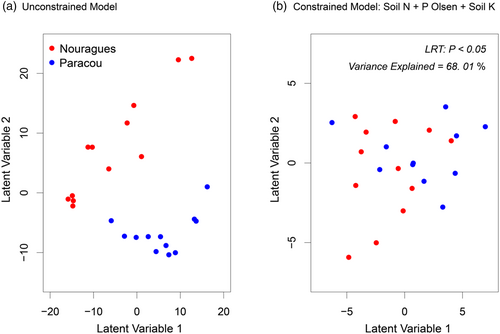

**FIGURE 1**

Ordination of the tree communities based on generalized linear latent variable models, with two latent variables and no predictors (a) and including soil nitrogen (N), potassium (K) and available phosphorus (P<sub>Olsen</sub>) as environmental predictors (b). Differences between the models were tested using a likelihood-ratio test, showing an increase in the variance explained by the environmental predictors.

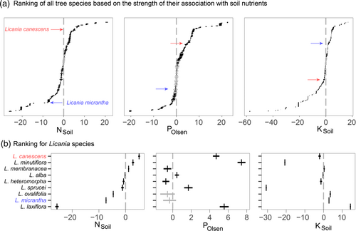

**FIGURE 2**

(a) Coefficient plot showing ranked point estimates (±95% CI) for the associations between 222 tree species and soil concentration of nitrogen (N), potassium (K), and available phosphorus (P<sub>Olsen</sub>) computed from the environmentally constrained model. Significant associations (95% CI of coefficients no overlapping with zero) between tree species and nutrients are highlighted in black; the ranking of the species differs in each panel; species labels are not shown for clarity. (b) Coefficient plot showing ranked point estimates for the species within the *Licania* genus.

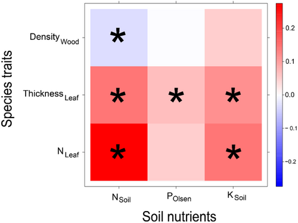

**FIGURE 3**

Level plot from a fourth corner generalized linear latent variable model including soil concentration of nitrogen (N), potassium (K), and available phosphorus (P) as environmental predictors of the tree community composition and interacting with wood density, leaf N concentration as a proportion (%) of dry mass, and leaf thickness, as the functional traits mediating tree species responses. * denote significant trait–environment interactions as indicated by lack of overlap with zero by 95% CI of trait-environment coefficients.

The functional volume was larger at Nouragues than at Paracou and the larger unique component of Nouragues was mainly associated with the presence of tree species with higher leaf N concentrations; species with greater wood density tended to occur at Paracou (Figure 4a,b) and there was less empty functional space at Nouragues than at Paracou (Figure 4c). Functional evenness of tree communities was positively related to soil N at plot level (*F*<sub>1,22</sub> = 18, *p* < 0.001, *r*<sup>2</sup><sub>adj</sub> = 0.41; Figure 5a), while their functional hole ratio was negatively related to soil N (slope for the soil N estimate: −33.47 ± 14.6, *F*<sub>3,20</sub> = 3.51, *p <* 0.05, *r*<sup>2</sup><sub>adj</sub> = 0.25; Figure 5b). There were no differences in other phylogenetic and functional diversity indices across study sites, topographic position or soil nutrient concentration gradients.

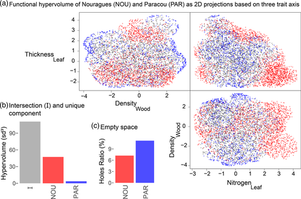

**FIGURE 4**

(a) Functional volume of tree communities at the Nouragues and Paracou study sites, shown as two-dimensional projections based on three trait axes (leaf thickness, sapwood density and leaf nitrogen concentration). (b) Intersection, unique components and (c) the hole ratio of the functional volumes.

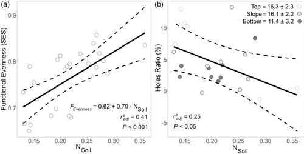

**FIGURE 5**

(a) Relationship between soil nitrogen concentration (N<sub>Soil</sub>) and functional evenness (standardized effect size). (b) Conditional relationship between hole ratio of the community trait volume and soil N concentration (N<sub>Soil</sub>) using bottom soil N as topographic factor control.

We found a strong phylogenetic conservatism of leaf N across all tree lineages (*λ* = 0.49, *p <* 0.001), even excluding the Fabaceae from the phylogeny (*λ* = 0.37, *p <* 0.001; see Table S1). Despite that, many sister-species pairs showed highly contrasting values of leaf N (Figure 6a). The evolutionary lability of this trait was particularly evident in the recently diversified genus *Licania* (Chrysobalanaceae), where sister species, such as *L. canescens* and *L. micrantha*, show divergent evolutionary trajectories for leaf N concentration (Figure 6b) that mirrors their distributions associated with N rich and N poor soils, respectively (cf. Figure 2b). Similar examples can be found in other clades such as those within the Chrysophylloideae species complex (Sapotaceae). Tree species like *Chrysophyllum lucentifolium* or *Pouteria retinervis* have relatively high leaf N and are significantly associated with N-rich soils, while their corresponding relatives *C. cuneifolium* and *P. melanopoda* present relatively lower leaf N and are strongly associated with N poor soils (Figures S7 and S8).

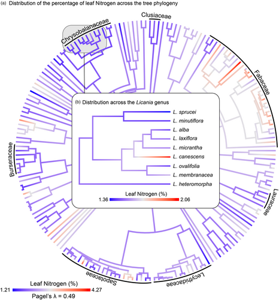

**FIGURE 6**

Distribution of leaf nitrogen (N), as a proportion (%) of dry mass, across the phylogeny of the 222 tree species (a) and the *Licania* genus (b). Ancestral trait states at internal nodes were estimated using maximum likelihood, assuming a Brownian motion model of trait evolution.

## 4 DISCUSSION

Our results demonstrate that soil nutrient concentration is a prevalent force during tree community assembly of tropical forests. Nutrient-based species selection was found to be mediated by key functional traits of the leaf and wood economics spectrum, such as leaf N concentration and thickness and sapwood density. We found a positive relationship between nutrient concentration and the functional space of tropical tree communities, while at the local scale, greater nutrient concentration led to a more regular filling of this trait space, with fewer vacant functional niches. The coupling between evolutionary patterns of leaf N concentration and the spatial distribution of tree species due to soil N concentration indicates the influence of nutrient availability on tree species diversification via habitat specialization.

Heterogeneous patterns of soil nutrient stocks and cycling rates and the importance of nutrients in species distributions and the dynamics and function of tropical forests have long been recognized (Vitousek and Sanford, 1986). Tropical forests comprise a mosaic of edaphic types across local to landscape scales, reflected in the spatial segregation of tree species (John et al., 2007), where the distribution of up to 77% of tree species may be described as non-random and associated with nutrient availability (Clark et al., 1998, 1999; Condit et al., 2013; John et al., 2007; Turner et al., 2018). Our results build on these previous findings by showing the composition of tropical forest tree species is associated with a combination of N, P and K in soils, rather than P alone, because 89% of the tree species in this study were strongly associated with the soil concentration of at least one of these nutrients. These results support a recent meta-analysis of nutrient addition experiments that showed that both P and N limitations are widespread across montane and lowland tropical forests (Wright, 2019). While studies of the effects of micronutrient limitation on plant growth are limited, our finding shows the importance of K concurs with a long-term fertilization experiment, in which K limited the growth of tree seedlings (Santiago et al., 2012). Similarly, a recent observational study highlighted the importance of K and also other nutrients, such as calcium and magnesium, in shaping tree community composition across topographic levels in an Amazonian forest (Vaz, 2021), and the importance of calcium has also been shown to constrain the secondary succession of an afrotropical forest (Bauters et al., 2022). Overall, these studies support the general hypothesis that multiple elements contribute to the co-limitation of tropical forests (Kaspari, 2021; Kaspari & Powers, 2016).

Our work identified trait–environment relationships that drive this nutrient-based species selection. Greater concentrations of soil N were associated with tree species with higher N concentration in their leaves, higher leaf thickness and lower sapwood density. These results tend to agree with predictions of the global leaf and wood economics spectrum that posits a trade-off between construction costs and growth potential (Díaz et al., 2016). Under this framework, soil properties have been found to be dominant drivers of plant functional traits at a global scale, while there is a global trend for plant species with higher photosynthetic potential to be favoured in more fertile soils, due to higher leaf N concentrations (Joswig et al., 2021). Furthermore, a greater leaf thickness is related to a higher defensive capacity of costly leaves to extend their longevity, thereby warranting the energy return on investment (Reich, 2014). A lower wood density is related to faster growth rates which demand higher nutrient supply rates, so such a strategy is more easily afforded in more fertile soils (Chave et al., 2009). Other environmental factors, such as climate, have also been identified as key regulators of plant trait distributions at a global scale (Joswig et al., 2021). For example, water availability is of particular importance in tropical forests (Guillemot et al., 2022), and the interaction between the effect of drought and steep gradients in soil nutrient concentration produces functional trade-offs and contrasting responses across tree species (Umaña et al., 2021). However, we could not test for the interaction of water availability with soil nutrients given the similarity in mean annual precipitation between our two study sites. Moreover, it is also well established that plants can reciprocally affect soil chemistry underneath them in what is known as ‘Zinke’ effects (Waring et al., 2015). This may be particularly important for atmospherically derived elements like N compared to rock-derived elements like P and cations, and these plant-driven effects can substantially contribute to increase the heterogeneity of soil chemistry at small spatial scales (Waring et al., 2015). Therefore, while soil nutrients exert selection on certain plant attributes, those favoured plant species can bolster this nutritional selective effect, thus establishing an inter-dependent feed-back plant–soil elemental composition.

A greater concentration of nutrients was related to an expansion of the functional trait space defined by the tree communities. The size of this functional volume is related to the species richness of the tree community (Lamanna et al., 2014). Even though there were differences in the size of the species pools between our two study sites, it is important to note that the expansion of the trait space at the more nutrient-rich site was mainly associated with the presence of tree species with higher levels of leaf N concentrations. Additionally, soil N concentration was associated with a higher evenness of the abundance distribution across the functional trait space and there was a negative relationship between soil N concentration and the level of empty functional space in the trait volume, indicating that the phenotypic expression of tree communities as well as their ecological functioning can be modulated by abiotic conditions such as nutrient availability (Lamanna et al., 2014). These results provide evidence for the positive roles of soil N content in the regular and efficient occupation of available trait space and its reduction of vacant ecological niches (Blonder, 2016; Mason et al., 2005). Changes in tree community composition across soil nutrient gradients in tropical forests have been related to habitat filtering and environmental determinism (Kraft et al., 2008; Tuomisto et al., 2003); however, functional evenness and the rate of holes in the volume may be indicators of the breadth and filling of available functional niches in a given community, but they do not provide information about the drivers of assembly processes (Blonder, 2016; Mason et al., 2013). Consequently, it is not possible to discern whether environmental filtering, competitive exclusion or both mechanisms underlie the observed strong influence of nutrient concentration on community assembly of the tropical forests in this study. Given that variation in nutrient availability has been already reported to reverse the outcomes of competitive interactions among coexisting plant species (Levine et al., 1998), it is possible that this nutrient-based selection process may be the result of a reduced competitive performance through equalizing mechanisms in non-preferred habitats (Mayfield & Levine, 2010), but also be due to strict environmental filtering, the abiotic environment simply favouring the population growth of better adapted species through niche differences. Still, we should incorporate demographic parameters into the analyses if we are to properly link the observed patterns of trait distribution with the species coexistence mechanisms operating during community assembly.

In an insightful contribution, the botanist Alwyn Gentry reported that the distributions of the four species conforming the *Passiflora vitifolia* species complex (Passifloraceae) were segregated across the Amazonia according to edaphic properties. Gentry concluded that soil features linked to topographic position at a landscape level drive the high diversity and species turnover of Amazonian forests, and accordingly predicted that the distribution of many other plant groups would show similar patterns (Gentry, 1981). Several studies have since provided evidence for repeated independent evolution of habitat specialist taxa in closely related plant species (Fine et al., 2005; Savolainen et al., 2006; Schmitt et al., 2021). This common diversification process could be exacerbated by antagonistic biotic interactions such as herbivory (Fine et al., 2004). Our results support these previous findings by showing how many sister-species pairs such as in the recently diversified clade of the *Licania* genus (Chrysobalanaceae, Chave et al., 2020) or in the older Chrysophylloideae species complex (Sapotaceae, De Faria et al., 2017), present contrasting leaf N concentrations that mirror their patterns of abundance distribution across the natural gradients of soil N content. Similarly, a population genetics study carried out at one of our study sites has shown that species complexes within the *Symphonia* (Clusiaceae) and *Eschweilera* (Lecythidaceae) were differentiated according to soil nutrient distribution and chemistry (Schmitt et al., 2021). The same diversification process based on edaphic specialization has been suggested for the whole Protieae tribe (Burseraceae) (Fine et al., 2005). Sympatric speciation has been already reported for several plant species (Papadopulos et al., 2011; Savolainen et al., 2006), and it may be explained by the gradient hypothesis of diversification without isolation, which states that where two adjacent habitats select for contrasting traits in their respective populations, and hybrids of the incipient species are at a selective disadvantage (Rieseberg et al., 1995), species may then diverge as a result of parapatric speciation across a sharp environmental gradient (Endler, 1977). Overall, our study demonstrates that soil heterogeneity is a key driver of tropical forest diversity and function and that nutrient-related habitat specialization has left an evolutionary signature in tree species' elemental composition and their biogeochemical niche (Ashton, 1969; Sardans et al., 2021).

## AUTHOR CONTRIBUTIONS

Guille Peguero, Fernando Coello, Josep Peñuelas, Ivan A. Janssens and Jordi Sardans designed the study. Guille Peguero, Oriol Grau, Dolores Asensio, Ifigenia Urbina, Joan Llusià, Romà Ogaya, Leandro Van Langenhove, Lore T. Verryckt, Clément Stahl, Elodie A. Courtois and Laëtitia Bréchet conducted the field and laboratory work. Jérôme Chave and Bruno Hérault contributed data. Fernando Coello and Guille Peguero analysed the data. Jordi Sardans, Josep Peñuelas, Jérôme Chave and Bruno Hérault provided ideas for the analyses and interpretation. Guille Peguero and Fernando Coello led the writing of the manuscript and all other authors contributed to revisions. Guille Peguero and Fernando Coello contributed equally.

## ACKNOWLEDGEMENTS

This research was supported by the Spanish Government grant PID2019-110521GB-I00, the European Research Council Synergy grant ERC-2013-SyG 610028-IMBALANCE-P, the Fundación Ramón Areces project CIVP20A6621, and the Catalan Government grant SGR 2017-1005. We thank the staff of Nouragues (USR mixte LEEISA, CNRS, Cayenne) and Paracou (UMR Ecofog, CIRAD, INRAE, Kourou) research stations. Both facilities received support from ‘Investissement d'Avenir’ grants provided by the Agence Nationale de la Recherche (CEBA: ANR-10-LABX-25-01, ANAEE-France: ANR-11-INBS-0001). We thank Vincent Freycon for the identification and characterization of each topographical position and Pascal Petronelli for the botanical determination.

## CONFLICT OF INTEREST STATEMENT

The authors declare no conflict of interest.